# NFL 2020 Week 15

MAJ Daniel Baller

8/27/2019

## Instructor Group Predictions

This Week's Predictions

Week 15

| Game | Prediction | Winner | Correct | Correct Votes | Correct Percent |
| --- | --- | --- | --- | --- | --- |
| 1 | Las Vegas Raiders | Los Angeles Chargers | No | 0 | 0.0000 |
| 2 | Buffalo Bills | Buffalo Bills | Yes | 16 | 1.0000 |
| 3 | Green Bay Packers | Green Bay Packers | Yes | 16 | 1.0000 |
| 4 | Miami Dolphins | Miami Dolphins | Yes | 11 | 0.6875 |
| 5 | Seattle Seahawks | Seattle Seahawks | Yes | 14 | 0.8750 |
| 6 | San Francisco 49ers | Dallas Cowboys | No | 3 | 0.1875 |
| 7 | Tampa Bay Buccaneers | Tampa Bay Buccaneers | Yes | 14 | 0.8750 |
| 8 | Baltimore Ravens | Baltimore Ravens | Yes | 16 | 1.0000 |
| 9 | Indianapolis Colts | Indianapolis Colts | Yes | 16 | 1.0000 |
| 10 | Chicago Bears | Chicago Bears | Yes | 11 | 0.6875 |
| 11 | Tennessee Titans | Tennessee Titans | Yes | 16 | 1.0000 |
| 12 | Los Angeles Rams | New York Jets | No | 0 | 0.0000 |
| 13 | Arizona Cardinals | Arizona Cardinals | Yes | 11 | 0.6875 |
| 14 | Kansas City Chiefs | Kansas City Chiefs | Yes | 15 | 0.9375 |
| 15 | Cleveland Browns | Cleveland Browns | Yes | 15 | 0.9375 |
| 16 | Pittsburgh Steelers | Cincinnati Bengals | No | 0 | 0.0000 |

Our win percentage for the week is 0.75

Our season win percentage so far is 0.6561

Games picked this season 221

Correct Games this season 145

predictions this week

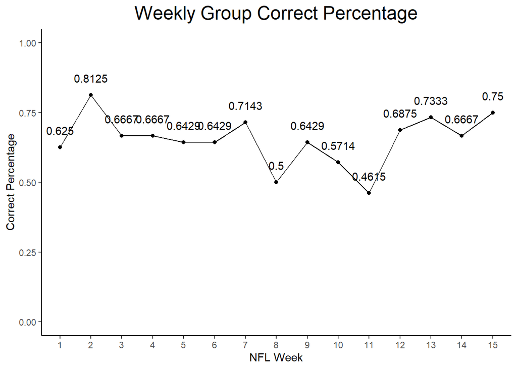

## Individual Predictions

Individual Results

Week 15

Name

Weekly # Correct

Percent

Weeks Picked

Season Percent

Adj Season Percent

Season Trend

Week 1

Week 2

Week 3

Week 4

Week 5

Week 6

Week 7

Week 8

Week 9

Week 10

Week 11

Week 12

Week 13

Week 14

Week 15

Gregory Minetos

9

14

10

12

8

8

12

7

10

7

7

11

9

9

12

0.7500

15

0.6561

0.6561

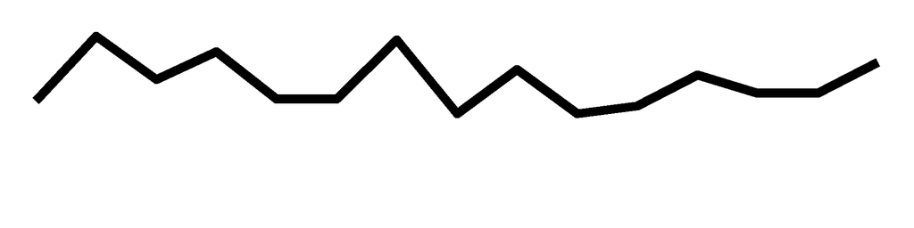

Michael Prokos

9

12

9

8

11

10

9

7

9

9

7

10

11

12

12

0.7500

15

0.6561

0.6561

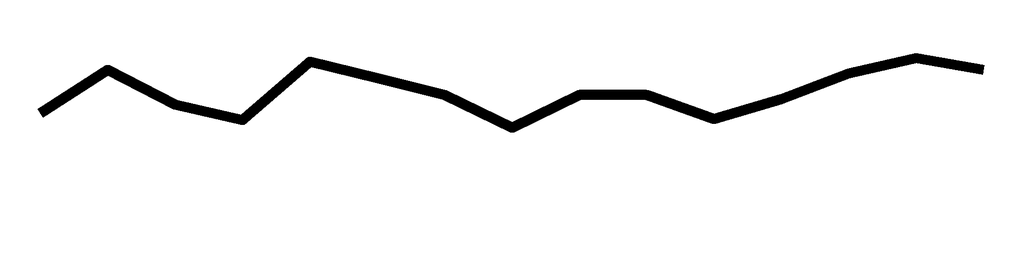

Josephine Cammack

9

11

12

10

9

9

11

7

6

8

NA

9

12

11

12

0.7500

14

0.6538

0.6102

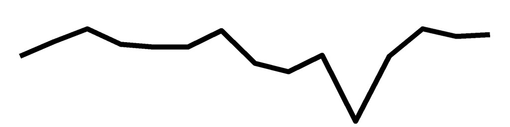

Margaret Wieczorek

11

14

9

9

8

NA

10

8

9

8

7

8

11

11

12

0.7500

14

0.6522

0.6087

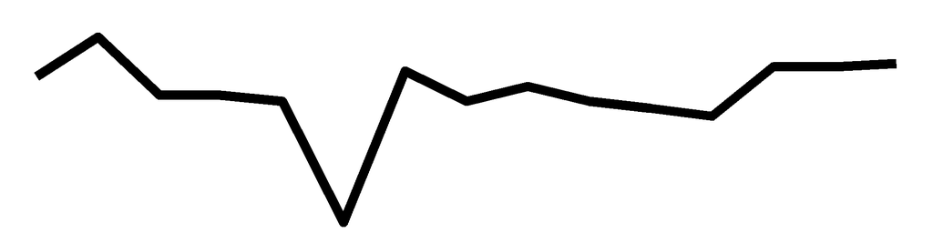

Kevin Cummiskey

13

11

9

9

10

7

9

5

10

9

7

12

10

10

12

0.7500

15

0.6471

0.6471

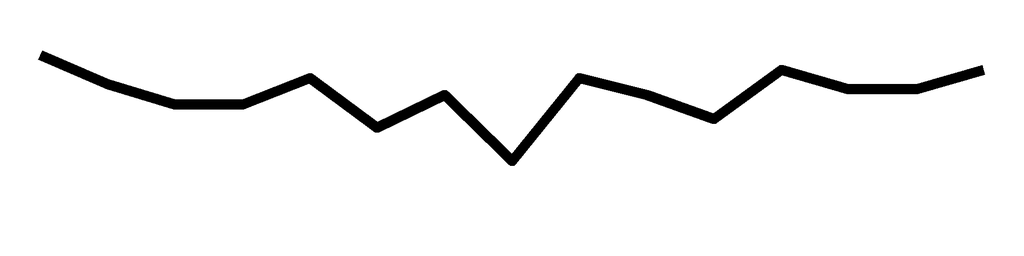

Eric Swenson

4

8

10

9

9

8

9

8

7

8

8

10

11

9

12

0.7500

15

0.5882

0.5882

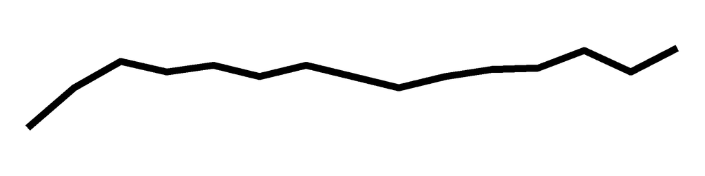

Tina Hartley

9

11

10

8

8

9

9

7

3

8

6

10

9

9

12

0.7500

15

0.5792

0.5792

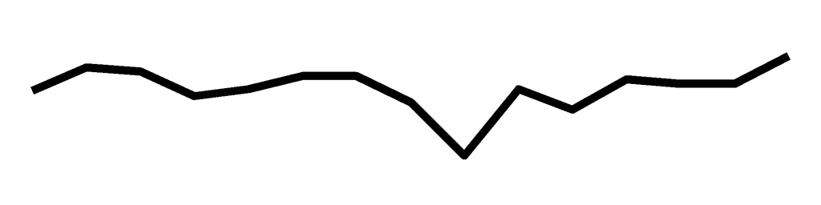

James Pleuss

9

12

10

12

7

8

10

9

9

10

7

10

12

12

11

0.6875

15

0.6697

0.6697

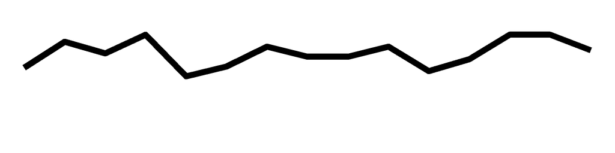

John Kearby

9

11

6

9

9

8

12

6

9

10

6

10

11

9

11

0.6875

15

0.6154

0.6154

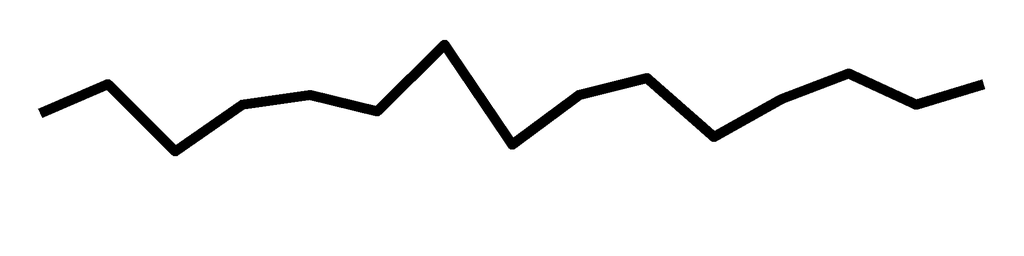

Blake Schwartz

10

9

10

10

10

9

9

6

5

8

7

9

11

10

11

0.6875

15

0.6063

0.6063

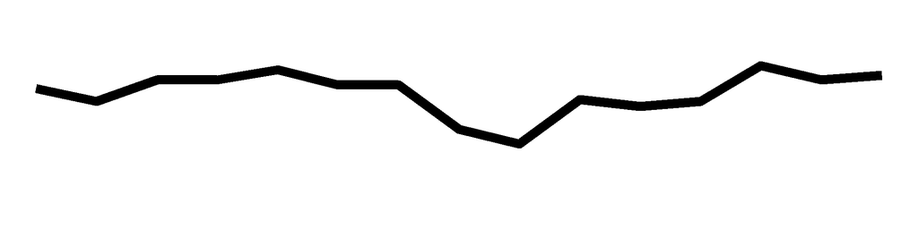

Kevin Quigley

8

8

9

10

10

8

8

6

8

7

9

10

NA

NA

11

0.6875

13

0.5864

0.5082

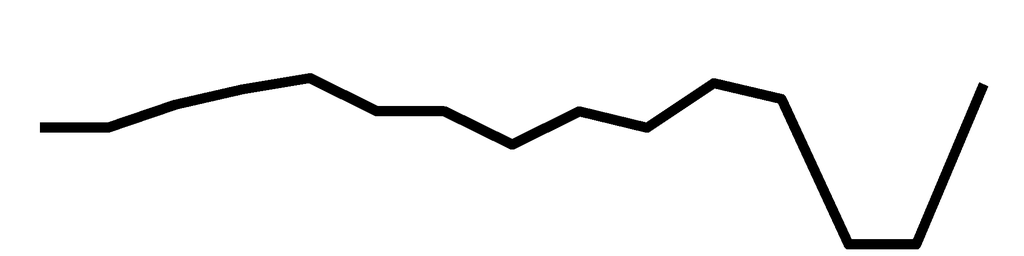

James Starling

15

12

9

12

10

NA

11

8

10

10

6

11

11

7

10

0.6250

14

0.6860

0.6403

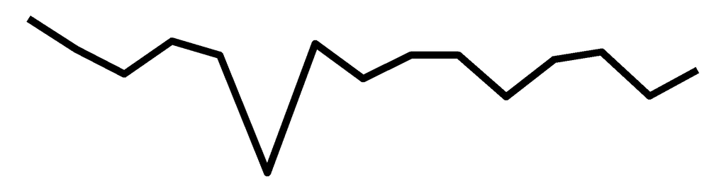

Daniel Baller

11

10

10

9

9

5

8

9

11

10

8

11

11

11

10

0.6250

15

0.6471

0.6471

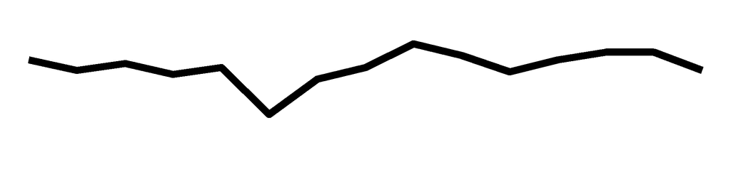

Gabriel Costa

9

12

6

9

10

7

9

7

10

10

9

NA

11

8

9

0.5625

14

0.6146

0.5736

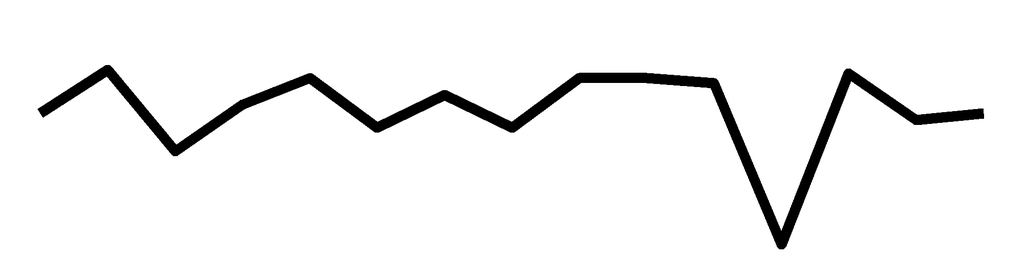

Nicholas Reisweber

9

10

10

8

10

7

8

8

10

9

6

14

9

8

9

0.5625

15

0.6109

0.6109

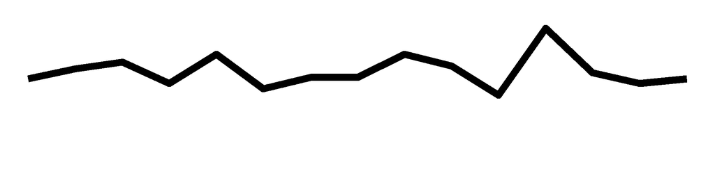

Timothy Moore

10

11

8

9

7

9

7

7

7

NA

NA

NA

9

10

8

0.5000

12

0.5730

0.4584

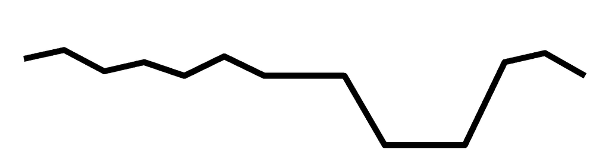

Shane Clark

10

14

9

9

9

9

10

NA

11

7

7

12

10

11

NA

0.0000

13

0.6702

0.5808

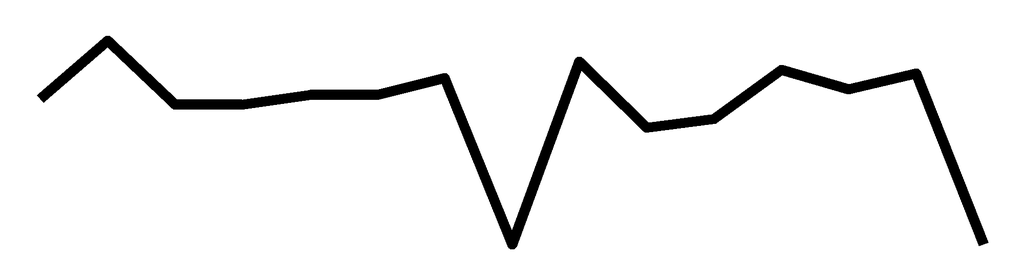

Daniel Richardson

13

11

10

10

8

NA

8

NA

NA

NA

NA

NA

NA

NA

NA

0.0000

6

0.6667

0.2667

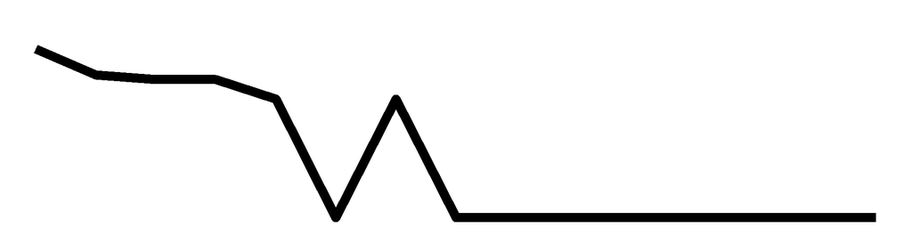

Travis Russell

11

8

8

11

10

10

10

8

NA

NA

7

NA

NA

NA

NA

0.0000

9

0.6336

0.3802

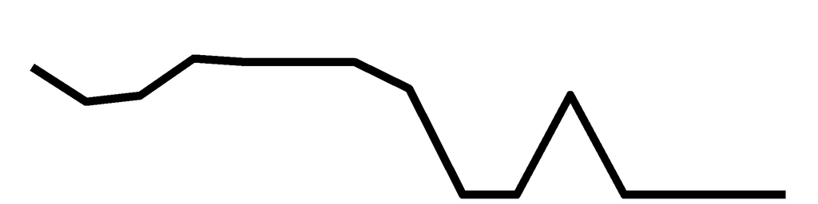

Welvin Lucero

9

11

9

10

NA

NA

11

8

NA

8

5

NA

NA

10

NA

0.0000

9

0.6136

0.3682

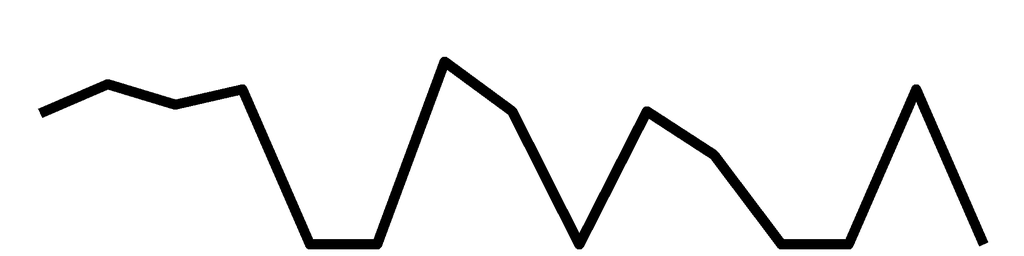

Frank Czerniakowski

7

13

10

9

8

6

9

6

11

5

9

11

9

12

NA

0.0000

14

0.6098

0.5691

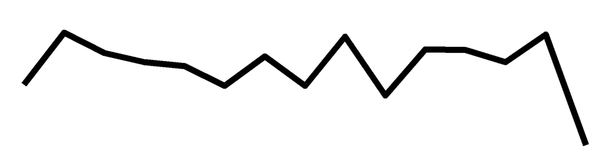

Andrew Lee

9

10

8

NA

NA

NA

NA

NA

NA

NA

NA

NA

NA

NA

NA

0.0000

3

0.5745

0.1149

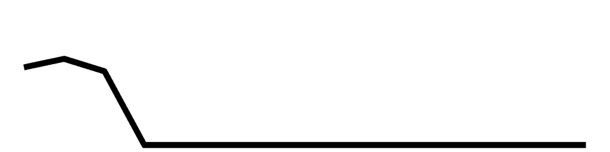

Congrats Gregory Minetos for having the best picks this week, with a correct percentage of 0.75, Congrats Michael Prokos for having the best picks this week, with a correct percentage of 0.75, Congrats Josephine Cammack for having the best picks this week, with a correct percentage of 0.75, Congrats Margaret Wieczorek for having the best picks this week, with a correct percentage of 0.75, Congrats Kevin Cummiskey for having the best picks this week, with a correct percentage of 0.75, Congrats Eric Swenson for having the best picks this week, with a correct percentage of 0.75, Congrats Tina Hartley for having the best picks this week, with a correct percentage of 0.75

| Name | Week 1 | Week 2 | Week 3 | Week 4 | Week 5 | Week 6 | Week 7 | Week 8 | Week 9 | Week 10 | Week 11 | Week 12 | Week 13 | Week 14 | Week 15 | Percent | Weeks Picked | Season Percent | Adj Season Percent | Season Trend |
| --- | --- | --- | --- | --- | --- | --- | --- | --- | --- | --- | --- | --- | --- | --- | --- | --- | --- | --- | --- | --- |
| Gregory Minetos | 9 | 14 | 10 | 12 | 8 | 8 | 12 | 7 | 10 | 7 | 7 | 11 | 9 | 9 | 12 | 0.7500 | 15 | 0.6561 | 0.6561 |  |
| Michael Prokos | 9 | 12 | 9 | 8 | 11 | 10 | 9 | 7 | 9 | 9 | 7 | 10 | 11 | 12 | 12 | 0.7500 | 15 | 0.6561 | 0.6561 |  |
| Josephine Cammack | 9 | 11 | 12 | 10 | 9 | 9 | 11 | 7 | 6 | 8 | NA | 9 | 12 | 11 | 12 | 0.7500 | 14 | 0.6538 | 0.6102 |  |
| Margaret Wieczorek | 11 | 14 | 9 | 9 | 8 | NA | 10 | 8 | 9 | 8 | 7 | 8 | 11 | 11 | 12 | 0.7500 | 14 | 0.6522 | 0.6087 |  |
| Kevin Cummiskey | 13 | 11 | 9 | 9 | 10 | 7 | 9 | 5 | 10 | 9 | 7 | 12 | 10 | 10 | 12 | 0.7500 | 15 | 0.6471 | 0.6471 |  |
| Eric Swenson | 4 | 8 | 10 | 9 | 9 | 8 | 9 | 8 | 7 | 8 | 8 | 10 | 11 | 9 | 12 | 0.7500 | 15 | 0.5882 | 0.5882 |  |
| Tina Hartley | 9 | 11 | 10 | 8 | 8 | 9 | 9 | 7 | 3 | 8 | 6 | 10 | 9 | 9 | 12 | 0.7500 | 15 | 0.5792 | 0.5792 |  |
| James Pleuss | 9 | 12 | 10 | 12 | 7 | 8 | 10 | 9 | 9 | 10 | 7 | 10 | 12 | 12 | 11 | 0.6875 | 15 | 0.6697 | 0.6697 |  |
| John Kearby | 9 | 11 | 6 | 9 | 9 | 8 | 12 | 6 | 9 | 10 | 6 | 10 | 11 | 9 | 11 | 0.6875 | 15 | 0.6154 | 0.6154 |  |
| Blake Schwartz | 10 | 9 | 10 | 10 | 10 | 9 | 9 | 6 | 5 | 8 | 7 | 9 | 11 | 10 | 11 | 0.6875 | 15 | 0.6063 | 0.6063 |  |
| Kevin Quigley | 8 | 8 | 9 | 10 | 10 | 8 | 8 | 6 | 8 | 7 | 9 | 10 | NA | NA | 11 | 0.6875 | 13 | 0.5864 | 0.5082 |  |
| James Starling | 15 | 12 | 9 | 12 | 10 | NA | 11 | 8 | 10 | 10 | 6 | 11 | 11 | 7 | 10 | 0.6250 | 14 | 0.686 | 0.6403 |  |
| Daniel Baller | 11 | 10 | 10 | 9 | 9 | 5 | 8 | 9 | 11 | 10 | 8 | 11 | 11 | 11 | 10 | 0.6250 | 15 | 0.6471 | 0.6471 |  |
| Gabriel Costa | 9 | 12 | 6 | 9 | 10 | 7 | 9 | 7 | 10 | 10 | 9 | NA | 11 | 8 | 9 | 0.5625 | 14 | 0.6146 | 0.5736 |  |
| Nicholas Reisweber | 9 | 10 | 10 | 8 | 10 | 7 | 8 | 8 | 10 | 9 | 6 | 14 | 9 | 8 | 9 | 0.5625 | 15 | 0.6109 | 0.6109 |  |
| Timothy Moore | 10 | 11 | 8 | 9 | 7 | 9 | 7 | 7 | 7 | NA | NA | NA | 9 | 10 | 8 | 0.5000 | 12 | 0.573 | 0.4584 |  |
| Shane Clark | 10 | 14 | 9 | 9 | 9 | 9 | 10 | NA | 11 | 7 | 7 | 12 | 10 | 11 | NA | 0.0000 | 13 | 0.6702 | 0.5808 |  |
| Daniel Richardson | 13 | 11 | 10 | 10 | 8 | NA | 8 | NA | NA | NA | NA | NA | NA | NA | NA | 0.0000 | 6 | 0.6667 | 0.2667 |  |
| Travis Russell | 11 | 8 | 8 | 11 | 10 | 10 | 10 | 8 | NA | NA | 7 | NA | NA | NA | NA | 0.0000 | 9 | 0.6336 | 0.3802 |  |
| Welvin Lucero | 9 | 11 | 9 | 10 | NA | NA | 11 | 8 | NA | 8 | 5 | NA | NA | 10 | NA | 0.0000 | 9 | 0.6136 | 0.3682 |  |
| Frank Czerniakowski | 7 | 13 | 10 | 9 | 8 | 6 | 9 | 6 | 11 | 5 | 9 | 11 | 9 | 12 | NA | 0.0000 | 14 | 0.6098 | 0.5691 |  |
| Andrew Lee | 9 | 10 | 8 | NA | NA | NA | NA | NA | NA | NA | NA | NA | NA | NA | NA | 0.0000 | 3 | 0.5745 | 0.1149 |  |

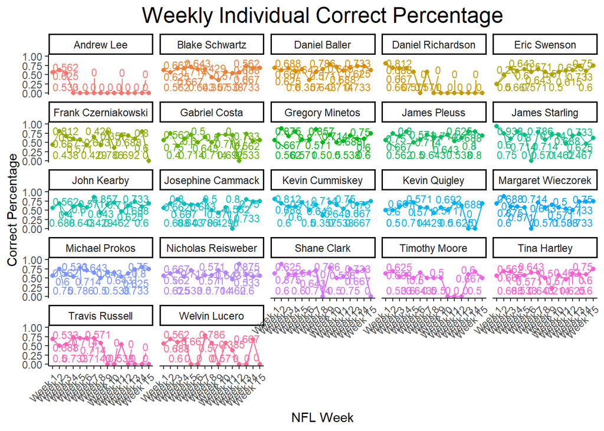

## MA206 Group Predictions

This Week's MA206 Predictions

Week 15

| Game | Prediction | Winner | Correct | Correct Votes | Correct Percent |
| --- | --- | --- | --- | --- | --- |
| 1 | Las Vegas Raiders | Los Angeles Chargers | No | 0 | 0.0000 |
| 2 | Buffalo Bills | Buffalo Bills | Yes | 5 | 0.8333 |
| 3 | Green Bay Packers | Green Bay Packers | Yes | 6 | 1.0000 |
| 4 | Miami Dolphins | Miami Dolphins | Yes | 6 | 1.0000 |
| 5 | Seattle Seahawks | Seattle Seahawks | Yes | 6 | 1.0000 |
| 6 | San Francisco 49ers | Dallas Cowboys | No | 2 | 0.3333 |
| 7 | Tampa Bay Buccaneers | Tampa Bay Buccaneers | Yes | 6 | 1.0000 |
| 8 | Baltimore Ravens | Baltimore Ravens | Yes | 6 | 1.0000 |
| 9 | Indianapolis Colts | Indianapolis Colts | Yes | 6 | 1.0000 |
| 10 | Chicago Bears | Chicago Bears | Yes | 4 | 0.6667 |
| 11 | Tennessee Titans | Tennessee Titans | Yes | 5 | 0.8333 |
| 12 | Los Angeles Rams | New York Jets | No | 0 | 0.0000 |
| 13 | Arizona Cardinals | Arizona Cardinals | Yes | 6 | 1.0000 |
| 14 | Kansas City Chiefs | Kansas City Chiefs | Yes | 4 | 0.6667 |
| 15 | Cleveland Browns | Cleveland Browns | Yes | 6 | 1.0000 |
| 16 | Pittsburgh Steelers | Cincinnati Bengals | No | 0 | 0.0000 |

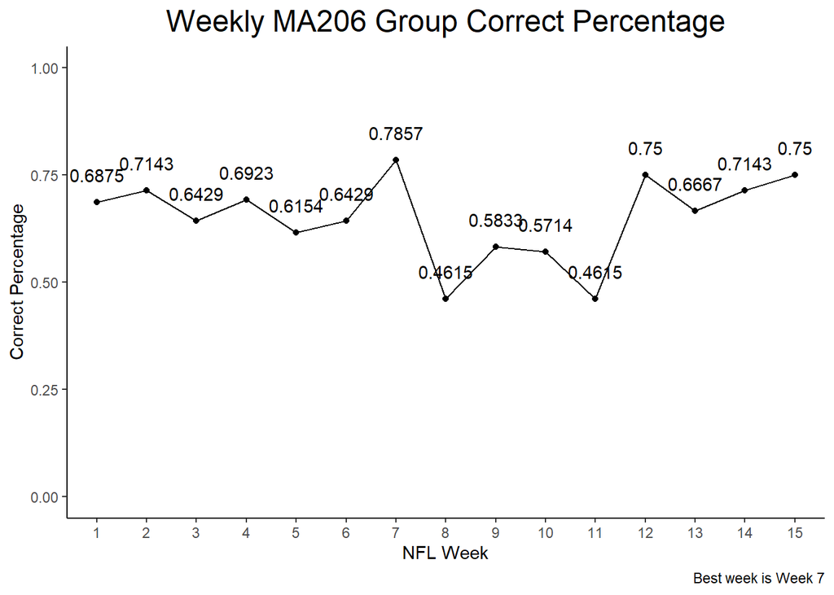

# Cadet Individual Results

MA206 Individual Results

Week 15

Name

Weekly # Correct

Percent

Weeks Picked

Season Percent

Adj Season Percent

Season Trend

Week 1

Week 2

Week 3

Week 4

Week 5

Week 6

Week 7

Week 8

Week 9

Week 10

Week 11

Week 12

Week 13

Week 14

Week 15

Caroline Swenson

8

12

11

13

7

8

10

NA

8

9

8

NA

12

11

12

0.7500

13

0.6754

0.5853

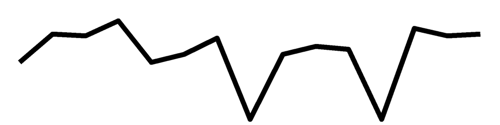

Gabriela Peralta

11

8

9

NA

8

8

10

6

NA

8

6

10

12

NA

12

0.7500

12

0.6102

0.4882

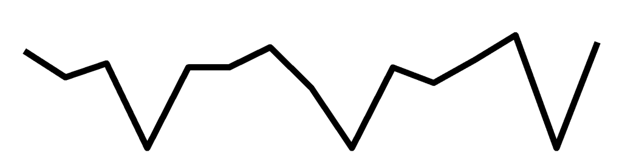

Joshua Loyd

11

9

8

NA

6

9

NA

6

10

8

NA

10

9

11

12

0.7500

12

0.6089

0.4871

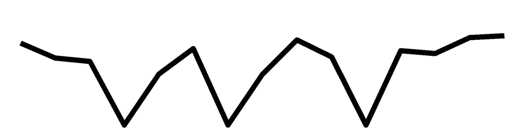

Paige Lennon

NA

NA

NA

11

10

8

11

8

6

8

6

9

11

10

11

0.6875

12

0.6264

0.5011

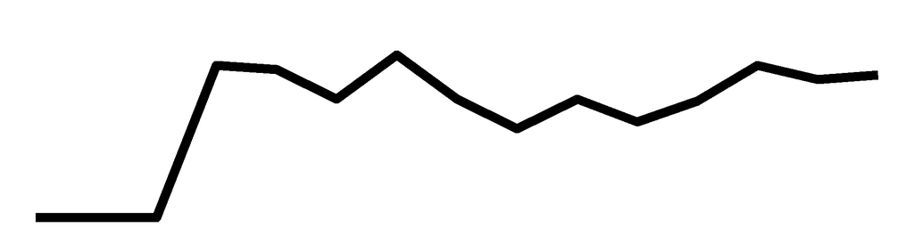

Sydney Shannon

10

9

8

9

8

7

9

5

8

10

8

10

11

10

11

0.6875

15

0.6018

0.6018

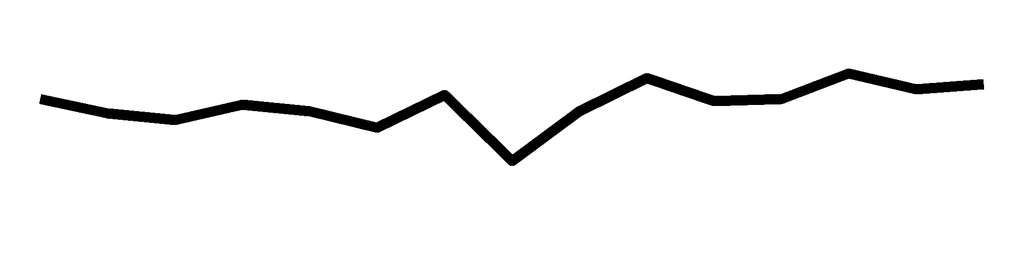

John White

10

11

10

8

12

9

11

6

9

9

8

10

8

11

10

0.6250

15

0.6425

0.6425

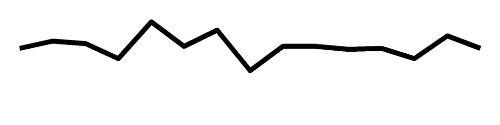

Thomas Bizub

10

14

8

11

8

9

10

8

10

12

9

11

9

10

NA

0.0000

14

0.6780

0.6328

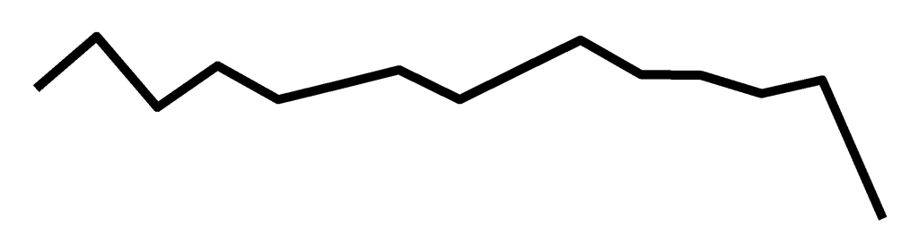

Kieran Place

12

11

8

NA

10

10

9

NA

NA

NA

NA

NA

NA

NA

NA

0.0000

6

0.6742